# IE 582 HW-1

Serhat Arca

17 Ekim 2018

## Task 1a)

The aim of this task is to decide whether the bookmakers are good at deciding over 2.5 odd. In order to do that 5 bookmakers, namely Pinnacle, bet-at-home, Unibet, BetVictor and bet365, are selected and the implied “over” probability average in a bin for each bookmaker versus the fraction of games finished over for the corresponding bin are plotted. For a succesful bookmaker, we would expect the points to scatter around x=y line. The empirical and probabilistic results for the bookmakers are given in Figure 1-5:

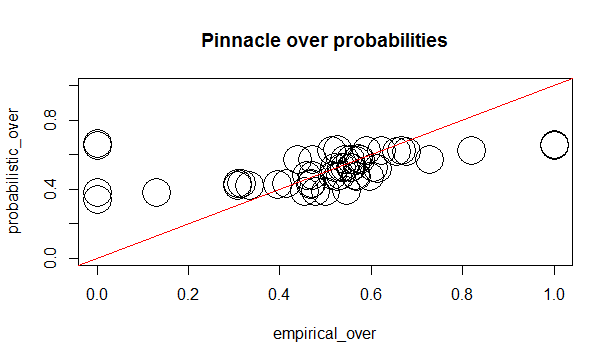

Figure 1: Empirical and probabilistic results for Pinnacle.

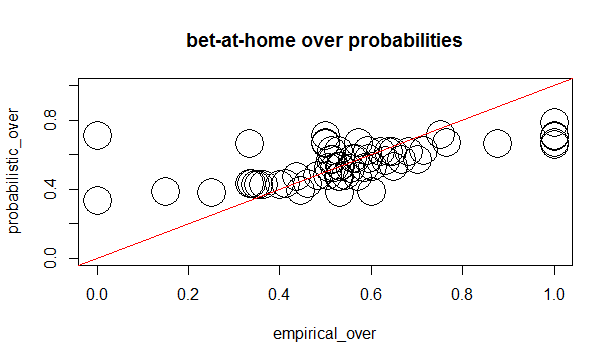

Figure 2: Empirical and probabilistic results for bet-at-home.

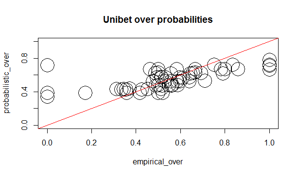

Figure 3: Empirical and probabilistic results for Unibet.

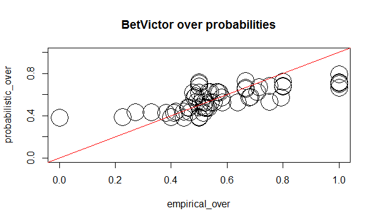

Figure 4: Empirical and probabilistic results for BetVictor.

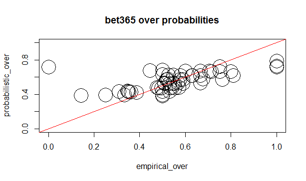

Figure 5: Empirical and probabilistic results for bet365.

In Figures 1-5, the empirical over is calculated by dividing the number of games ended as “over”" in the corresponding bin, by the total number of games in the corresponding bin. The probabilistic over is found by taking the averages of the “over” probabilities (recirocal of the odds given by the bookmakers) in a bin.

An investigation of Figures 1-5 reveals that, there is a very large deviation from x=y line at empirical over probabilities at 0 and 1. This can be explained with the presence of very few matches in the corresponding bins, which can be seen by making use of the summary table in the given code. The empirical and probabilistic results agree well at an interval around 0.4 -0.6.

n Figures 1-5, there are some results over the x=y line in the empirical over range of 0.2-0.4. On the other hand, there are several results under the x=y line over the range from 0.7-0.8. These results indicate that, when the bookmakers give higher odds (lower probabilistic over), a lower fraction of the games end with an “over” score.

## Task 1b)

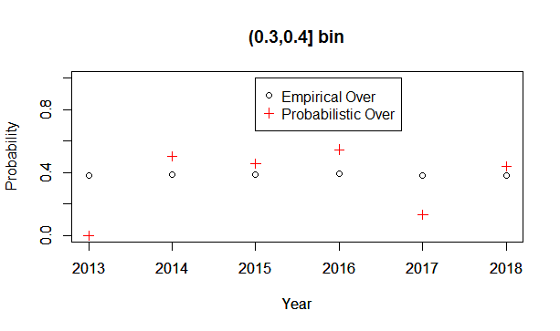

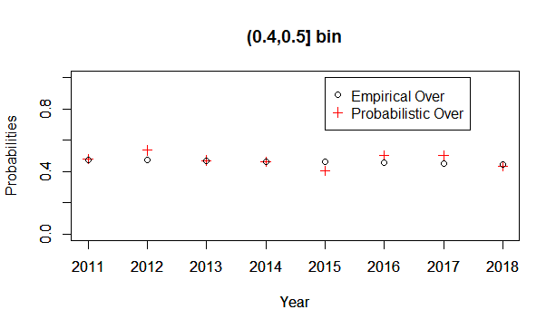

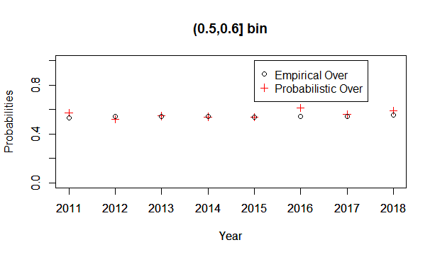

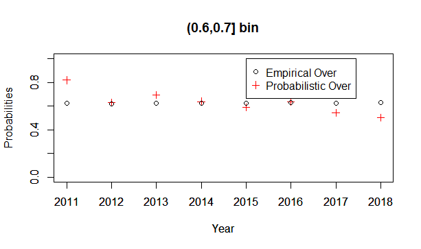

## Task 2)

The aim of this task is to observe the changes in odds for match results. For this purpose, bet365 is chosen and the data is filtered so that only “odd1”" results and year 2018 is included. The change in odds is given in Figure 10:

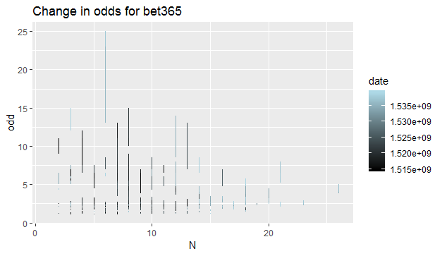

Figure 10: Change in odds for bet365

An investigation of Figure 10 reveals that there is no significant correlation between the number of bets (N) and the odds. In addition to that, it can be seen that the odds might change at a very large interval, from around 12 to 25. Finally, it is possible to conclude that there is no increasing or decreasing trend over time for the odds given by the bookmakers.

## Appendix

Code for Task 1

require(data.table) require(anytime)

matches_file_path=‘C:/Users/asus/Desktop/df9b1196-e3cf-4cc7-9159-f236fe738215_matches.rds’ odd_details_file_path=‘C:/Users/asus/Desktop/df9b1196-e3cf-4cc7-9159-f236fe738215_odd_details.rds’

matches=readRDS(matches_file_path)

odds=readRDS(odd_details_file_path) matches=unique(matches)

#transform unix time to date matches[,match_date:=anydate(date)] #transform unix time to date time matches[,match_time:=anytime(date)] matches[,Year:=year(match_time)]

#order by home team and match date (decreasing) matches=matches[order(home,-match_time)] matches[,c(“HomeGoals”,“AwayGoals”):=tstrsplit(score,‘:’)] #transform characters to numeric for scores matches$HomeGoals=as.numeric(matches$HomeGoals) matches[,AwayGoals:=as.numeric(AwayGoals)] #calculate total goals matches[,TotalGoals:=HomeGoals+AwayGoals]

# mark over under matches[,IsOver:=0] matches[TotalGoals>2.5,IsOver:=1]

#filter na scores matches=na.omit(matches,cols=“score”)

#filter over under 2.5 odds_ov_un=odds[betType==‘ou’ & totalhandicap==‘2.5’]

#remove total handicap odds_ov_un[,totalhandicap:=NULL]

#order data in ascending date odds_ov_un=odds_ov_un[order(matchId, oddtype,bookmaker,date)]

odds_ov_un_initial=odds_ov_un[,list(start_odd=odd[1]), by=list(matchId,oddtype,bookmaker)]

odds_ov_un_final=odds_ov_un[,list(final_odd=odd[.N]), by=list(matchId,oddtype,bookmaker)]

#transform to wide format  
wide_odds_initial=dcast(odds_ov_un_initial, matchId~oddtype+bookmaker, value.var=‘start_odd’)

#transform to long long_ov_un_initial=melt(wide_odds_initial,id.vars=1, measure.vars=2:ncol(wide_odds_initial))

#1- Pinnacle #get pinnacle initial over under odds pinnacle_over_under=odds_ov_un_initial[bookmaker==‘Pinnacle’]

pinnacle_wide=dcast(pinnacle_over_under, matchId~oddtype, value.var=‘start_odd’)

# join odds with matches merged_matches=merge(matches,pinnacle_wide,by=‘matchId’)

#setkey(matches,matchId) #setkey(pinnacle_wide,matchId) #joined_matches=pinnacle_wide[matches]

merged_matches[,probOver:=1/over] merged_matches[,probUnder:=1/under]

merged_matches[,totalProb:=probOver+probUnder]

merged_matches[,probOver:=probOver/totalProb] merged_matches[,probUnder:=probUnder/totalProb]

merged_matches=merged_matches[complete.cases(merged_matches)] merged_matches[,totalProb:=NULL]

cutpoints=seq(0,1,0.05) merged_matches[,odd_cut_over:=cut(probOver,cutpoints)]

summary_table=merged_matches[,list(empirical_over=mean(IsOver), probabilistic_over=mean(probOver),.N), by=list(Year,odd_cut_over)] plot(summary_table[,list(empirical_over,probabilistic_over)],main=‘Pinnacle over probabilities’,xlim = c(0,1), ylim = c(0,1),cex=4) abline(0,1,col=‘red’) summary_table=summary_table[order(Year)]

#2- bet-at-home #get bet-at-home initial over under odds bet_at_home_over_under=odds_ov_un_initial[bookmaker==‘bet-at-home’]

bet_at_home_wide=dcast(bet_at_home_over_under, matchId~oddtype, value.var=‘start_odd’)

# join odds with matches merged_matches2=merge(matches,bet_at_home_wide,by=‘matchId’)

#setkey(matches,matchId) #setkey(bet_at_home_wide,matchId) #joined_matches=bet_at_home_wide[matches]

merged_matches2[,probOver:=1/over] merged_matches2[,probUnder:=1/under]

merged_matches2[,totalProb:=probOver+probUnder]

merged_matches2[,probOver:=probOver/totalProb] merged_matches2[,probUnder:=probUnder/totalProb]

merged_matches2=merged_matches2[complete.cases(merged_matches2)] merged_matches2[,totalProb:=NULL]

cutpoints=seq(0,1,0.05) merged_matches2[,odd_cut_over:=cut(probOver,cutpoints)]

summary_table2=merged_matches2[,list(empirical_over=mean(IsOver), probabilistic_over=mean(probOver),.N), by=list(Year,odd_cut_over)] plot(summary_table2[,list(empirical_over,probabilistic_over)],main=‘bet-at-home over probabilities’,xlim = c(0,1), ylim = c(0,1),cex=4) abline(0,1,col=‘red’) summary_table2=summary_table2[order(Year)]

#3- Unibet #Unibet initial over under odds Unibet_over_under=odds_ov_un_initial[bookmaker==‘Unibet’]

Unibet_wide=dcast(Unibet_over_under, matchId~oddtype, value.var=‘start_odd’)

# join odds with matches merged_matches3=merge(matches,Unibet_wide,by=‘matchId’)

#setkey(matches,matchId) #setkey(Unibet_wide,matchId) #joined_matches=Unibet_wide[matches]

merged_matches3[,probOver:=1/over] merged_matches3[,probUnder:=1/under]

merged_matches3[,totalProb:=probOver+probUnder]

merged_matches3[,probOver:=probOver/totalProb] merged_matches3[,probUnder:=probUnder/totalProb]

merged_matches3=merged_matches3[complete.cases(merged_matches3)] merged_matches3[,totalProb:=NULL]

cutpoints=seq(0,1,0.05) merged_matches3[,odd_cut_over:=cut(probOver,cutpoints)]

summary_table3=merged_matches3[,list(empirical_over=mean(IsOver), probabilistic_over=mean(probOver),.N), by=list(Year,odd_cut_over)] plot(summary_table3[,list(empirical_over,probabilistic_over)], main=‘Unibet over probabilities’,xlim = c(0,1), ylim = c(0,1),cex=4) abline(0,1,col=‘red’) summary_table3=summary_table3[order(Year)]

#4- BetVictor #BetVictor initial over under odds BetVictor_over_under=odds_ov_un_initial[bookmaker==‘BetVictor’]

BetVictor_wide=dcast(BetVictor_over_under, matchId~oddtype, value.var=‘start_odd’)

# join odds with matches merged_matches4=merge(matches,BetVictor_wide,by=‘matchId’)

#setkey(matches,matchId) #setkey(BetVictor_wide,matchId) #joined_matches=BetVictor_wide[matches]

merged_matches4[,probOver:=1/over] merged_matches4[,probUnder:=1/under]

merged_matches4[,totalProb:=probOver+probUnder]

merged_matches4[,probOver:=probOver/totalProb] merged_matches4[,probUnder:=probUnder/totalProb]

merged_matches4=merged_matches4[complete.cases(merged_matches4)] merged_matches4[,totalProb:=NULL]

cutpoints=seq(0,1,0.05) merged_matches4[,odd_cut_over:=cut(probOver,cutpoints)]

summary_table4=merged_matches4[,list(empirical_over=mean(IsOver), probabilistic_over=mean(probOver),.N), by=list(Year,odd_cut_over)] plot(summary_table4[,list(empirical_over,probabilistic_over)],main=‘BetVictor over probabilities’,xlim = c(0,1), ylim = c(0,1),cex=4) abline(0,1,col=‘red’) summary_table4=summary_table4[order(Year)]

#5- bet365 #bet365 initial over under odds bet365_over_under=odds_ov_un_initial[bookmaker==‘bet365’]

bet365_wide=dcast(bet365_over_under, matchId~oddtype, value.var=‘start_odd’)

# join odds with matches merged_matches5=merge(matches,bet365_wide,by=‘matchId’)

#setkey(matches,matchId) #setkey(bet365_wide,matchId) #joined_matches=bet365_wide[matches]

merged_matches5[,probOver:=1/over] merged_matches5[,probUnder:=1/under]

merged_matches5[,totalProb:=probOver+probUnder]

merged_matches5[,probOver:=probOver/totalProb] merged_matches5[,probUnder:=probUnder/totalProb]

merged_matches5=merged_matches5[complete.cases(merged_matches5)] merged_matches5[,totalProb:=NULL]

cutpoints=seq(0,1,0.05) merged_matches5[,odd_cut_over:=cut(probOver,cutpoints)]

summary_table5=merged_matches5[,list(empirical_over=mean(IsOver), probabilistic_over=mean(probOver),.N), by=list(Year,odd_cut_over)] plot(summary_table5[,list(empirical_over,probabilistic_over)],main=‘bet365 over probabilities’,xlim = c(0,1), ylim = c(0,1),cex=4) abline(0,1,col=‘red’) summary_table5=summary_table5[order(Year)]

cutpoints_b=seq(0,1,0.1) merged_matches_b=merged_matches[,odd_cut_over:=cut(probOver,cutpoints_b)]

summary_table_b=merged_matches_b[,list(empirical_over=mean(IsOver), probabilistic_over=mean(probOver),.N), by=list(Year,odd_cut_over)]

summary_table_b=summary_table_b[order(Year)] bin1 =summary_table_b[odd_cut_over=="(0.3,0.4]“] plot(bin1[,list(Year,empirical_over)], pch=3, ylim = c(0,1), main=”(0.3,0.4] bin“, ylab=‘Probability’, col=”red“) par(new=TRUE) plot(bin1[,list(Year, probabilistic_over)],ylab=’’, ylim = c(0,1)) legend(2015,1, c(”Empirical Over“,”Probabilistic Over“),pch=c(1,3), col =c(”black“,”red"))

bin2 =summary_table_b[odd_cut_over=="(0.4,0.5]“] plot(bin2[,list(Year,empirical_over)],pch=3, ylim = c(0,1), main=”(0.4,0.5] bin“, ylab=‘Probabilities’, col=”red“) par(new=TRUE) plot(bin2[,list(Year, probabilistic_over)],ylab=’’, ylim = c(0,1)) legend(2015,1, c(”Empirical Over“,”Probabilistic Over“), pch=c(1,3), col =c(”black“,”red"))

bin3 =summary_table_b[odd_cut_over=="(0.5,0.6]“] plot(bin3[,list(Year,empirical_over)],pch=3, ylim = c(0,1), main=”(0.5,0.6] bin“, ylab=‘Probabilities’, col=”red“) par(new=TRUE) plot(bin3[,list(Year, probabilistic_over)],ylab=’’, ylim = c(0,1)) legend(2015,1, c(”Empirical Over“,”Probabilistic Over“), pch=c(1,3), col =c(”black“,”red"))

bin4 =summary_table_b[odd_cut_over=="(0.6,0.7]“] plot(bin4[,list(Year,empirical_over)],pch=3, ylim = c(0,1), main=”(0.6,0.7] bin“, ylab=‘Probabilities’, col=”red“) par(new=TRUE) plot(bin4[,list(Year, probabilistic_over)],ylab=’’, ylim = c(0,1)) legend(2015,1, c(”Empirical Over“,”Probabilistic Over“), pch=c(1,3), col =c(”black“,”red"))

## Task 2

require(data.table) require(anytime) require(ggplot2)

matches_file_path=‘C:/Users/asus/Desktop/df9b1196-e3cf-4cc7-9159-f236fe738215_matches.rds’ odd_details_file_path=‘C:/Users/asus/Desktop/df9b1196-e3cf-4cc7-9159-f236fe738215_odd_details.rds’

matches=readRDS(matches_file_path)

odds=readRDS(odd_details_file_path) matches=unique(matches)

#transform unix time to date matches[,match_date:=anydate(date)] #transform unix time to date time matches[,match_time:=anytime(date)] matches[,Year:=year(match_time)]

#order by home team and match date (decreasing) matches=matches[order(home,-match_time)] matches[,c(“HomeGoals”,“AwayGoals”):=tstrsplit(score,‘:’)] #transform characters to numeric for scores matches$HomeGoals=as.numeric(matches$HomeGoals) matches[,AwayGoals:=as.numeric(AwayGoals)]

#filter na scores matches=na.omit(matches,cols=“score”)

#filter over 1x2 odds_1x2=odds[betType==‘1x2’ & bookmaker==‘bet365’ & oddtype == ‘odd1’]

#transform unix time to date odds_1x2[,match_date:=anydate(date)] #transform unix time to date time odds_1x2[,match_time:=anytime(date)] odds_1x2[,Year:=year(match_time)]

#filter over 1x2 odds_1x2=odds_1x2[Year==2018]

#remove total handicap odds_1x2[,totalhandicap:=NULL]

#order data in ascending date odds_1x2=odds_1x2[order(matchId, oddtype,bookmaker,date)]

odds_1x2_initial=odds_1x2[,list(start_odd=odd[1]), by=list(matchId,oddtype,bookmaker)]

odds_1x2_final=odds_1x2[,list(final_odd=odd[.N]), by=list(matchId,oddtype,bookmaker)]

summary_table=odds_1x2[,list(date, odd,.N), by=list(matchId)] ggplot(summary_table,aes(x=N, y=odd, color=date))+geom_line(aes(group=matchId))+scale_color_gradient(low=“black”, high=“light blue”) + ggtitle(“Change in odds for bet365”)